# Customer Regularity Prediction: Hard Churn v.s. Rock Star

Task:

Given monthly record of each user: (1) Predict next period Churn (2) Predict next period Rock Star (3) Predict next period Regularity

Objectives:

(1) Predict soft churn and rock star in the next month; take action before they churn.

(2) Identify powerful indicator for retention，Increase of user retention rate by putting more effort on those factors

```python
# mode: 'small_dataset': using small dataset, used for debugging, runfaster;
# 'full_dataset', we will use the full dataset to get final models
# mode = 'small_dataset'
mode = 'full_dataset'
```

### 1. Gathering Data Source/ Preprocessing

1. Join the 2 tables
2. Create Target variables: (1) we consider churn and readingDayNum of next month as Target Variables (2) need to create new variable: if it is soft churn next month or not: for each sunscription ID, and each month, create: (Q4 need to be discussed) 'churn_next_month'(0,1),'soft_churn_next_month'(0,1),'rock_star_next_month','log_readingDayNum_next_month'
1. Create / remove variables Create variables from last month (1-2%improvement): readingDayNum_last_month + if it is NA Remove: ID, end date, etc.

```python
import matplotlib.pyplot as plt
import seaborn as sns
sns.set() # for plot styling
import numpy as np
import pandas as pd
%matplotlib inline

SFC = pd.read_csv("modeldataNoCensor.txt")
idtrain = pd.read_csv("idtrain.csv")
```

```python
# Join the 2 table so that we can split the train and test set
SFC_joined = pd.merge(SFC, idtrain, how='inner', on = 'SubscriptionId').copy()
SFC_joined['churn'] = SFC_joined['churn'].to_frame().copy()

# Create predictive variables readingDayNum_next_month and churn_next_month
SFC_joined = SFC_joined.sort_values(['SubscriptionId', 'month'], ascending=[True, False]).copy()
SFC_joined['readingDayNum_next_month'] = SFC_joined.groupby(['SubscriptionId'])['readingDayNum'].shift(1)
SFC_joined['readingDayNum_last_month'] = SFC_joined.groupby(['SubscriptionId'])['readingDayNum'].shift(-1) # David
SFC_joined['churn_next_month'] = SFC_joined.groupby(['SubscriptionId'])['churn'].shift(1)
SFC_joined['churn_last_month'] = SFC_joined.groupby(['SubscriptionId'])['churn'].shift(-1) # David
SFC_joined = SFC_joined.dropna(subset=['churn_next_month']).copy()
SFC_joined = SFC_joined.dropna(subset=['readingDayNum_next_month']).copy()

# Use the data at t or 0 to replace the "NA" data at t-1
SFC_joined['readingDayNum_last_month'] = np.where(pd.isna(SFC_joined['readingDayNum_last_month']), SFC_joined['readingDayNum'], SFC_joined['readingDayNum_last_month'])
SFC_joined['churn_last_month'] = np.where(pd.isna(SFC_joined['churn_last_month']), SFC_joined['churn'], SFC_joined['churn_last_month'])
SFC_joined.head(5)
```

|  | SubscriptionId | start_date | stop_date | multiStop | ProductUc | DeliveryScheduleUc | leftCensored | censorDaysL | SubscriptionType | Description | ... | homePVPct | homePVDay | nonHomePVDay | sentimentScore | Unnamed: 0 | train | readingDayNum_next_month | readingDayNum_last_month | churn_next_month | churn_last_month |
| --- | --- | --- | --- | --- | --- | --- | --- | --- | --- | --- | --- | --- | --- | --- | --- | --- | --- | --- | --- | --- | --- |
| 3 | 11035696 | 2018-03-10 | 2018-08-07 | True | SfChron | 22222222.3 | 0 | 0 | D | eEdition | ... | 0.400000 | 4.000000 | 6.000000 | 0 | 1 | True | 1.0 | 3.0 | 1.0 | 0.0 |
| 2 | 11035696 | 2018-03-10 | 2018-08-07 | True | SfChron | 22222222.3 | 0 | 0 | D | eEdition | ... | 0.250000 | 2.666667 | 8.000000 | 0 | 1 | True | 1.0 | 3.0 | 0.0 | 0.0 |
| 1 | 11035696 | 2018-03-10 | 2018-08-07 | True | SfChron | 22222222.3 | 0 | 0 | D | eEdition | ... | 0.666667 | 2.000000 | 1.000000 | 0 | 1 | True | 3.0 | 1.0 | 0.0 | 0.0 |
| 0 | 11035696 | 2018-03-10 | 2018-08-07 | True | SfChron | 22222222.3 | 0 | 0 | D | eEdition | ... | 0.500000 | 2.000000 | 2.000000 | -1 | 1 | True | 3.0 | 1.0 | 0.0 | 0.0 |
| 5 | 11766665 | 2018-06-19 | 2018-08-08 | True | SfChron | 22222222.1 | 0 | 0 | D | Universal Digital Access | ... | 0.000000 | 0.000000 | 2.222222 | -6 | 2 | True | 7.0 | 9.0 | 1.0 | 0.0 |

5 rows × 128 columns

```python
# Tranform some data
import datetime
SFC_joined['start_datetime'] = pd.to_datetime(SFC_joined.start_date)
# extract year, month, day
SFC_joined['start_date_year'] = SFC_joined['start_datetime'].dt.year
SFC_joined['start_date_month'] = SFC_joined['start_datetime'].dt.month
SFC_joined['start_date_day'] = SFC_joined['start_datetime'].dt.day

# delete stop date, start date and start datetime
SFC_joined = SFC_joined.drop(['stop_date', 'start_date', 'start_datetime', 'SubscriptionId'], axis=1).copy()

pd.set_option('display.max_columns', None)
SFC_joined.head()
```

|  | multiStop | ProductUc | DeliveryScheduleUc | leftCensored | censorDaysL | SubscriptionType | Description | month | churn | time | pv | readingDayNum | sessionNum | timePV | pvDay | sessionDay | entropy | device_type | mobileUse | desktopUse | tabletUse | referrer_type | first_hit_referrer_type | geo_city | geo_region | geo_country | ad_block_status | abDisabledPct | abEnabledPct | … |
| --- | --- | --- | --- | --- | --- | --- | --- | --- | --- | --- | --- | --- | --- | --- | --- | --- | --- | --- | --- | --- | --- | --- | --- | --- | --- | --- | --- | --- | --- | --- |
| 3 | True | SfChron | 22222222.3 | 0 | 0 | D | eEdition | 4 | 0 | 345.345000 | 10 | 1 | 2 | 34.534500 | 10.000000 | 2.000000 | 0.943348 | Desktop | 0.000000 | 1.000000 | 0.0 | Inside Your Site | Typed/Bookmarked | davis | California | United States | abDisabled | 1.00 | 0.00 | … |
| 2 | True | SfChron | 22222222.3 | 0 | 0 | D | eEdition | 3 | 0 | 3925.938673 | 32 | 3 | 5 | 122.685584 | 10.666667 | 1.666667 | 0.692239 | Desktop | 0.000000 | 1.000000 | 0.0 | Inside Your Site | Typed/Bookmarked | davis | California | United States | abDisabled | 1.00 | 0.00 | … |
| 1 | True | SfChron | 22222222.3 | 0 | 0 | D | eEdition | 2 | 0 | 820.444000 | 9 | 3 | 4 | 91.160444 | 3.000000 | 1.333333 | 0.636514 | Desktop | 0.000000 | 1.000000 | 0.0 | Inside Your Site | Typed/Bookmarked | davis | California | United States | abDisabled | 1.00 | 0.00 | … |
| 0 | True | SfChron | 22222222.3 | 0 | 0 | D | eEdition | 1 | 0 | 282.506667 | 4 | 1 | 1 | 70.626667 | 4.000000 | 1.000000 | 1.039721 | Desktop | 0.000000 | 1.000000 | 0.0 | Inside Your Site | Typed/Bookmarked | davis | California | United States | abDisabled | 0.75 | 0.25 | … |
| 5 | True | SfChron | 22222222.1 | 0 | 0 | D | Universal Digital Access | 1 | 0 | 473.258833 | 20 | 9 | 11 | 23.662942 | 2.222222 | 1.222222 | 1.070047 | Mobile Phone | 0.842105 | 0.157895 | 0.0 | Inside Your Site | Others | sacramento | California | United States | abDisabled | 0.00 | 0.00 | … |

```python
# Train- Test Split
train = SFC_joined[SFC_joined['train'] == True].copy()
print('train size: ', len(train))
test = SFC_joined[SFC_joined['train'] != True].copy()
print('test size: ', len(test))
```

```
train size:  36073
test size:  17886
```

```python
# if we are in test mode, only use a small part of data
if mode == 'small_dataset':
    train = train[:2000].copy()
    print('train size: ', len(train))
    test = test[:1000].copy()
    print('test size: ', len(test))
```

### 2. Feature Engineering

#### (1) Variable characteristics & Missing data imputation

```python
# make list of variables  types
# numerical: discrete vs continuous
discrete = [var for var in train.columns if train[var].dtype!='O' and train[var].nunique() <= 2 and var != 'start_date_year']
continuous = [var for var in train.columns if train[var].dtype!='O' and var not in discrete]

# categorical
categorical = [var for var in train.columns if train[var].dtype=='O' ]

print('There are {} discrete variables'.format(len(discrete)))
print('There are {} continuous variables'.format(len(continuous)))
print('There are {} categorical variables'.format(len(categorical)))
```

```
There are 9 discrete variables
There are 108 continuous variables
There are 11 categorical variables
```

```python
discrete
```

```
['multiStop',
 'leftCensored',
 'censorDaysL',
 'churn',
 'isEngage',
 'adBlock',
 'train',
 'churn_next_month',
 'churn_last_month']
```

```python
# train['multiStop'] = np.where(train['multiStop'] == True, 1, 0).copy()
# new = train[discrete]
# # use 0 and 1 instead of True and False
# new.head()
```

```python
continuous[0:10]
```

```
['DeliveryScheduleUc',
 'month',
 'time',
 'pv',
 'readingDayNum',
 'sessionNum',
 'timePV',
 'pvDay',
 'sessionDay',
 'entropy']
```

```python
categorical[0:10]
```

```
['ProductUc',
 'SubscriptionType',
 'Description',
 'device_type',
 'referrer_type',
 'first_hit_referrer_type',
 'geo_city',
 'geo_region',
 'geo_country',
 'ad_block_status']
```

```python
# numerical variable does not miss any data
train.select_dtypes(exclude='O').isnull().mean().mean()
```

```
0.0
```

```python
# categorical have missing data
train.select_dtypes(include='O').isnull().mean()
```

```
ProductUc                  0.000000
SubscriptionType           0.000000
Description                0.000000
device_type                0.319990
referrer_type              0.000000
first_hit_referrer_type    0.000000
geo_city                   0.319990
geo_region                 0.319990
geo_country                0.319990
ad_block_status            0.323206
season                     0.000000
dtype: float64
```

```python
# Let's fill na
train.fillna('Missing', inplace=True)
test.fillna('Missing', inplace=True)
```

#### (2) Encode Categorical variable (Rare-one-hot-encoding)

```python
# let's inspect the variable values
for var in categorical:
    print(var, len(train[var].unique()))

# geo_city 1000+, geo_region 100+, geo_country 50+ have too many variables, need to reduce them.
```

```
ProductUc 1
SubscriptionType 2
Description 8
device_type 4
referrer_type 7
first_hit_referrer_type 6
geo_city 1242
geo_region 191
geo_country 60
ad_block_status 4
season 4
```

```python
# let's explore examples in which variables have several categories, say more than 10
multi_cat_cols = []
for col in train.columns:
    if train[col].dtypes =='O': # if variable  is categorical
        if train[col].nunique() >= 10: # and has more than 10 categories
            multi_cat_cols.append(col)  # add to the list
print(multi_cat_cols) # and print the percentage of observations within each category
```

```
['geo_city', 'geo_region', 'geo_country']
```

```python
# check variable frequency, find a resonable threshod (0.01)
for var in multi_cat_cols:
    print((train[var].value_counts() / len(train)).sort_values()[-10:])
```

```
richmond         0.009010
sacramento       0.009231
(not set)        0.009287
new york         0.009564
san rafael       0.013168
san jose         0.014498
berkeley         0.014720
oakland          0.044632
san francisco    0.195437
Missing          0.319990
Name: geo_city, dtype: float64
District of Columbia    0.003548
Florida                 0.003964
Hawaii                  0.004075
Nevada                  0.004241
Washington              0.004713
Texas                   0.006431
Oregon                  0.008178
New York                0.011227
Missing                 0.319990
California              0.575056
Name: geo_region, dtype: float64
Costa Rica        0.000499
Philippines       0.000527
France            0.000610
Italy             0.000665
Japan             0.000693
Mexico            0.000915
Canada            0.001109
United Kingdom    0.001275
Missing           0.319990
United States     0.667896
Name: geo_country, dtype: float64
```

```python
def find_non_rare_labels(df, variable, tolerance):
    temp = df.groupby([variable])[variable].count() / len(df)
    non_rare = [x for x in temp.loc[temp>tolerance].index.values]
    return non_rare

def rare_encoding(X_train, X_test, variable, tolerance):

    X_train = X_train.copy()
    X_test = X_test.copy()
    # find the most frequent category
    frequent_cat = find_non_rare_labels(X_train, variable, tolerance)
    # re-group rare labels
    X_train[variable] = np.where(X_train[variable].isin(
        frequent_cat), X_train[variable], 'Rare')
    X_test[variable] = np.where(X_test[variable].isin(
        frequent_cat), X_test[variable], 'Rare')
    return X_train, X_test

for variable in multi_cat_cols:
    train, test = rare_encoding(train, test, variable, 0.01)

for var in categorical:
    print(var, len(train[var].unique()))
```

```
ProductUc 1
SubscriptionType 2
Description 8
device_type 4
referrer_type 7
first_hit_referrer_type 6
geo_city 7
geo_region 4
geo_country 3
ad_block_status 4
season 4
```

```python
# One-hot-encoding for categorical variables
train_dummies = pd.get_dummies(train[categorical])
test_dummies = pd.get_dummies(test[categorical])
# Get missing columns in the training test
missing_cols = set( train_dummies.columns ) - set( test_dummies.columns )
# Add a missing column in test set with default value equal to 0
for c in missing_cols:
    test_dummies[c] = 0
print(train_dummies.shape)
print(test_dummies.shape)
train_dummies.head()
```

```
(36073, 50)
(17886, 50)
```

|  | ProductUc_SfChron | SubscriptionType_D | SubscriptionType_P | Description_Fri-Sun | Description_Mon-Sat | Description_Mon-Sun | Description_Sun | Description_Universal Digital Access | Description_Wed-Sun | Description_eEdition | Description_iPad | device_type_Desktop | device_type_Missing | device_type_Mobile Phone | device_type_Tablet | referrer_type_Inside Your Site | referrer_type_NoRead | referrer_type_Other Web Sites | referrer_type_Others | referrer_type_Search Engines | referrer_type_Social Networks | referrer_type_Typed/Bookmarked | first_hit_referrer_type_NoRead | first_hit_referrer_type_Other Web Sites | first_hit_referrer_type_Others | first_hit_referrer_type_Search Engines | first_hit_referrer_type_Social Networks | first_hit_referrer_type_Typed/Bookmarked | geo_city_Missing | … |
| --- | --- | --- | --- | --- | --- | --- | --- | --- | --- | --- | --- | --- | --- | --- | --- | --- | --- | --- | --- | --- | --- | --- | --- | --- | --- | --- | --- | --- | --- | --- |
| 3 | 1 | 1 | 0 | 0 | 0 | 0 | 0 | 0 | 0 | 1 | 0 | 1 | 0 | 0 | 0 | 1 | 0 | 0 | 0 | 0 | 0 | 0 | 0 | 0 | 0 | 0 | 0 | 1 | 0 | … |
| 2 | 1 | 1 | 0 | 0 | 0 | 0 | 0 | 0 | 0 | 1 | 0 | 1 | 0 | 0 | 0 | 1 | 0 | 0 | 0 | 0 | 0 | 0 | 0 | 0 | 0 | 0 | 0 | 1 | 0 | … |
| 1 | 1 | 1 | 0 | 0 | 0 | 0 | 0 | 0 | 0 | 1 | 0 | 1 | 0 | 0 | 0 | 1 | 0 | 0 | 0 | 0 | 0 | 0 | 0 | 0 | 0 | 0 | 0 | 1 | 0 | … |
| 0 | 1 | 1 | 0 | 0 | 0 | 0 | 0 | 0 | 0 | 1 | 0 | 1 | 0 | 0 | 0 | 1 | 0 | 0 | 0 | 0 | 0 | 0 | 0 | 0 | 0 | 0 | 0 | 1 | 0 | … |
| 5 | 1 | 1 | 0 | 0 | 0 | 0 | 0 | 1 | 0 | 0 | 0 | 0 | 0 | 1 | 0 | 1 | 0 | 0 | 0 | 0 | 0 | 0 | 0 | 0 | 1 | 0 | 0 | 0 | 0 | … |

#### (3) For numerical variables, perform Distribution Transformation

Some Numerical Variables are extremely right-skewed

Compared log(1+x) transformation and Box-Cox transformation (1/x)

log(1+x) is slightly better for linear models

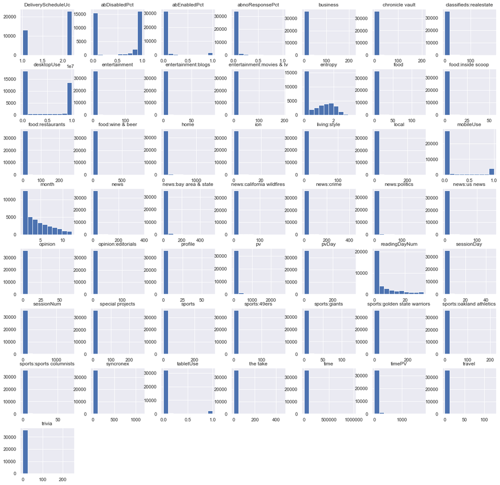

```python
# let's explore the distribution of the numerical variables
train[continuous[0:50]].hist(figsize=(20,20))
plt.show()
```

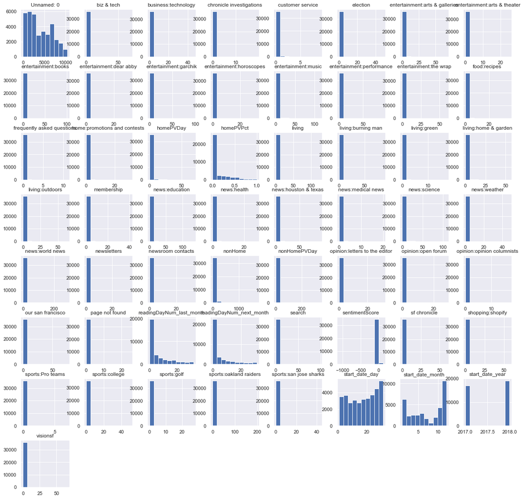

```python
train[continuous[51:]].hist(figsize=(20,20))
plt.show()
```

```python
# 'abDisabledPct', 'abEnabledPct', 'abnoResponsePct','entropy','Unnamed: 0','month','sentimentScore','start_date_month','start_date_day'
# these variables do not need to log
continuous_not_log = ['abDisabledPct', 'abEnabledPct', 'abnoResponsePct','entropy','Unnamed: 0','month','sentimentScore']
train_continuous = train[continuous_not_log]
test_continuous = test[continuous_not_log]
train_continuous.head()
```

|  | abDisabledPct | abEnabledPct | abnoResponsePct | entropy | Unnamed: 0 | month | sentimentScore |
| --- | --- | --- | --- | --- | --- | --- | --- |
| 3 | 1.00 | 0.00 | 0.0 | 0.943348 | 1 | 4 | 0 |
| 2 | 1.00 | 0.00 | 0.0 | 0.692239 | 1 | 3 | 0 |
| 1 | 1.00 | 0.00 | 0.0 | 0.636514 | 1 | 2 | 0 |
| 0 | 0.75 | 0.25 | 0.0 | 1.039721 | 1 | 1 | -1 |
| 5 | 0.00 | 0.00 | 0.0 | 1.070047 | 2 | 1 | -6 |

```python
# add transfromed columns
for var in continuous:
    if var not in continuous_not_log:
        if min(train[var]) > -1:
            train_continuous[var] = np.log(1.0 + train[var])
            test_continuous[var] = np.log(1.0 + test[var])
#             train_continuous[var] = 1.0 - (1.0 / (1.0 + train[var]))
#             test_continuous[var] = 1.0 - (1.0 / (1.0 + test[var]))
        else:
            train_continuous[var] = train[var]
            test_continuous[var] = test[var]
train_continuous.head()
```

|  | abDisabledPct | abEnabledPct | abnoResponsePct | entropy | Unnamed: 0 | month | sentimentScore | DeliveryScheduleUc | time | pv | readingDayNum | sessionNum | timePV | pvDay | sessionDay | mobileUse | desktopUse | tabletUse | home | news:bay area & state | syncronex | news | news:crime | news:politics | business | sports | sports:golden state warriors | sports:giants | food:restaurants | … |
| --- | --- | --- | --- | --- | --- | --- | --- | --- | --- | --- | --- | --- | --- | --- | --- | --- | --- | --- | --- | --- | --- | --- | --- | --- | --- | --- | --- | --- | --- | --- |
| 3 | 1.00 | 0.00 | 0.0 | 0.943348 | 1 | 4 | 0 | 16.916603 | 5.847435 | 2.397895 | 0.693147 | 1.098612 | 3.570504 | 2.397895 | 1.098612 | 0.000000 | 0.693147 | 0.0 | 1.609438 | 0.000000 | 1.791759 | 0.693147 | 0.0 | 0.0 | 0.00000 | 0.000000 | 0.0 | 0.0 | 0.0 | … |
| 2 | 1.00 | 0.00 | 0.0 | 0.692239 | 1 | 3 | 0 | 16.916603 | 8.275615 | 3.496508 | 1.386294 | 1.791759 | 4.817743 | 2.456736 | 0.980829 | 0.000000 | 0.693147 | 0.0 | 2.197225 | 0.000000 | 3.178054 | 0.000000 | 0.0 | 0.0 | 0.00000 | 0.000000 | 0.0 | 0.0 | 0.0 | … |
| 1 | 1.00 | 0.00 | 0.0 | 0.636514 | 1 | 2 | 0 | 16.916603 | 6.711064 | 2.302585 | 1.386294 | 1.609438 | 4.523531 | 1.386294 | 0.847298 | 0.000000 | 0.693147 | 0.0 | 1.945910 | 0.000000 | 1.386294 | 0.000000 | 0.0 | 0.0 | 0.00000 | 0.000000 | 0.0 | 0.0 | 0.0 | … |
| 0 | 0.75 | 0.25 | 0.0 | 1.039721 | 1 | 1 | -1 | 16.916603 | 5.647236 | 1.609438 | 0.693147 | 0.693147 | 4.271467 | 1.609438 | 0.693147 | 0.000000 | 0.693147 | 0.0 | 1.098612 | 0.693147 | 0.000000 | 0.000000 | 0.0 | 0.0 | 0.00000 | 0.000000 | 0.0 | 0.0 | 0.0 | … |
| 5 | 0.00 | 0.00 | 0.0 | 1.070047 | 2 | 1 | -6 | 16.916603 | 6.161753 | 3.044522 | 2.302585 | 2.484907 | 3.205302 | 1.170071 | 0.798508 | 0.610909 | 0.146603 | 0.0 | 0.000000 | 2.484907 | 0.000000 | 0.000000 | 0.0 | 0.0 | 1.94591 | 0.693147 | 0.0 | 0.0 | 0.0 | … |

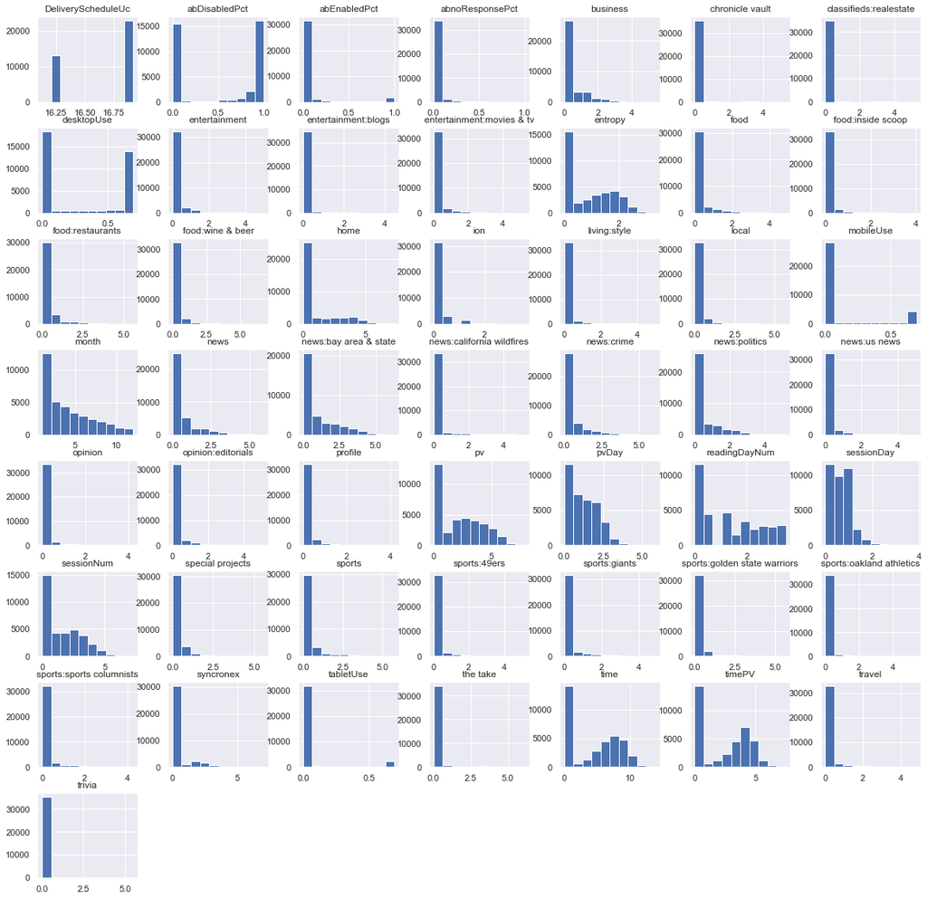

```python
# the distribution after transformation
train_continuous[continuous[0:50]].hist(figsize=(20,20))
plt.show()
```

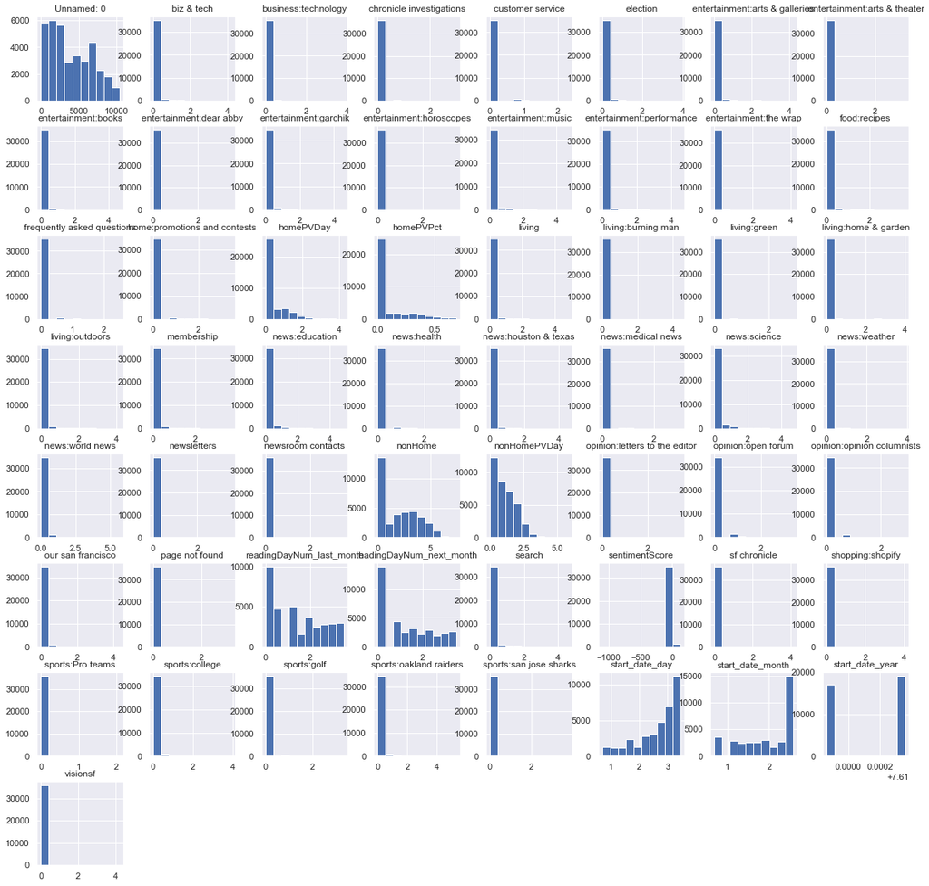

```python
train_continuous[continuous[51:]].hist(figsize=(20,20))
plt.show()
```

#### (4) Scale the range of variables to (0-1)

```python
train_continuous.describe()
```

|  | abDisabledPct | abEnabledPct | abnoResponsePct | entropy | Unnamed: 0 | month | sentimentScore | DeliveryScheduleUc | time | pv | readingDayNum | sessionNum | timePV | pvDay | sessionDay | mobileUse | desktopUse | tabletUse | home | news:bay area & state | syncronex | news | news:crime | news:politics | business | sports | sports:golden state warriors | sports:giants | food:restaurants | … |
| --- | --- | --- | --- | --- | --- | --- | --- | --- | --- | --- | --- | --- | --- | --- | --- | --- | --- | --- | --- | --- | --- | --- | --- | --- | --- | --- | --- | --- | --- | --- |
| count | 36073.000000 | 36073.000000 | 36073.000000 | 36073.000000 | 36073.000000 | 36073.000000 | 36073.000000 | 36073.000000 | 36073.000000 | 36073.000000 | 36073.000000 | 36073.000000 | 36073.000000 | 36073.000000 | 36073.000000 | 36073.000000 | 36073.000000 | 36073.000000 | 36073.000000 | 36073.000000 | 36073.000000 | 36073.000000 | 36073.000000 | 36073.000000 | 36073.000000 | 36073.000000 | 36073.000000 | 36073.000000 | 36073.000000 | … |
| mean | 0.526006 | 0.079186 | 0.020595 | 0.855621 | 3963.389737 | 4.242065 | -6.028415 | 16.661224 | 4.364509 | 2.172315 | 1.318033 | 1.565034 | 2.338960 | 1.138605 | 0.639929 | 0.117815 | 0.306242 | 0.060419 | 0.960578 | 0.889578 | 0.381715 | 0.477055 | 0.357930 | 0.408110 | 0.368505 | 0.259405 | 0.171543 | 0.192876 | 0.227984 | … |
| std | 0.472011 | 0.235166 | 0.078594 | 0.859487 | 2750.639901 | 2.801880 | 20.893715 | 0.336984 | 3.874236 | 1.945883 | 1.167962 | 1.467738 | 2.058340 | 0.978341 | 0.525379 | 0.239962 | 0.327820 | 0.181865 | 1.550221 | 1.256963 | 0.935945 | 0.861351 | 0.784732 | 0.772153 | 0.720097 | 0.681675 | 0.594250 | 0.605218 | 0.609902 | … |
| min | 0.000000 | 0.000000 | 0.000000 | 0.000000 | 1.000000 | 1.000000 | -1102.000000 | 16.129146 | 0.000000 | 0.000000 | 0.000000 | 0.000000 | 0.000000 | 0.000000 | 0.000000 | 0.000000 | 0.000000 | 0.000000 | 0.000000 | 0.000000 | 0.000000 | 0.000000 | 0.000000 | 0.000000 | 0.000000 | 0.000000 | 0.000000 | 0.000000 | 0.000000 | … |
| 25% | 0.000000 | 0.000000 | 0.000000 | 0.000000 | 1595.000000 | 2.000000 | -4.000000 | 16.223456 | 0.000000 | 0.000000 | 0.000000 | 0.000000 | 0.000000 | 0.000000 | 0.000000 | 0.000000 | 0.000000 | 0.000000 | 0.000000 | 0.000000 | 0.000000 | 0.000000 | 0.000000 | 0.000000 | 0.000000 | 0.000000 | 0.000000 | 0.000000 | 0.000000 | … |
| 50% | 0.808511 | 0.000000 | 0.000000 | 0.693147 | 3376.000000 | 4.000000 | 0.000000 | 16.916603 | 5.162471 | 2.079442 | 1.098612 | 1.386294 | 2.903123 | 1.098612 | 0.693147 | 0.000000 | 0.030191 | 0.000000 | 0.000000 | 0.000000 | 0.000000 | 0.000000 | 0.000000 | 0.000000 | 0.000000 | 0.000000 | 0.000000 | 0.000000 | 0.000000 | … |
| 75% | 1.000000 | 0.000000 | 0.000000 | 1.639821 | 6351.000000 | 6.000000 | 0.000000 | 16.916603 | 7.830548 | 3.713572 | 2.302585 | 2.639057 | 4.192111 | 1.909543 | 0.916291 | 0.000000 | 0.693147 | 0.000000 | 1.609438 | 1.609438 | 0.000000 | 0.693147 | 0.000000 | 0.693147 | 0.693147 | 0.000000 | 0.000000 | 0.000000 | 0.000000 | … |
| max | 1.000000 | 1.000000 | 1.000000 | 3.326143 | 10427.000000 | 12.000000 | 131.000000 | 16.916603 | 13.803601 | 7.879670 | 3.496508 | 7.286192 | 7.492430 | 5.839672 | 3.882937 | 0.693147 | 0.693147 | 0.693147 | 7.304516 | 6.285998 | 7.047517 | 5.953243 | 6.073045 | 5.187386 | 5.389072 | 5.755742 | 5.690359 | 4.882802 | 5.598422 | … |

```python
X_train_scaled = train_continuous.copy()
X_test_scaled = test_continuous.copy()

for var in continuous:
    X_train_scaled[var] = (train_continuous[var] - min(train_continuous[var]))/(max(train_continuous[var])-min(train_continuous[var]))
    X_test_scaled[var] = (test_continuous[var] - min(train_continuous[var]))/(max(train_continuous[var])-min(train_continuous[var]))
```

```python
X_train_scaled.describe()
```

|  | abDisabledPct | abEnabledPct | abnoResponsePct | entropy | Unnamed: 0 | month | sentimentScore | DeliveryScheduleUc | time | pv | readingDayNum | sessionNum | timePV | pvDay | sessionDay | mobileUse | desktopUse | tabletUse | home | news:bay area & state | syncronex | news | news:crime | news:politics | business | sports | sports:golden state warriors | sports:giants | food:restaurants | … |
| --- | --- | --- | --- | --- | --- | --- | --- | --- | --- | --- | --- | --- | --- | --- | --- | --- | --- | --- | --- | --- | --- | --- | --- | --- | --- | --- | --- | --- | --- | --- |
| count | 36073.000000 | 36073.000000 | 36073.000000 | 36073.000000 | 36073.000000 | 36073.000000 | 36073.000000 | 36073.000000 | 36073.000000 | 36073.000000 | 36073.000000 | 36073.000000 | 36073.000000 | 36073.000000 | 36073.000000 | 36073.000000 | 36073.000000 | 36073.000000 | 36073.000000 | 36073.000000 | 36073.000000 | 36073.000000 | 36073.000000 | 36073.000000 | 36073.000000 | 36073.000000 | 36073.000000 | 36073.000000 | 36073.000000 | … |
| mean | 0.526006 | 0.079186 | 0.020595 | 0.257241 | 0.380049 | 0.294733 | 0.888866 | 0.675691 | 0.316186 | 0.275686 | 0.376957 | 0.214794 | 0.312176 | 0.194978 | 0.164805 | 0.169970 | 0.441813 | 0.087166 | 0.131505 | 0.141517 | 0.054163 | 0.080134 | 0.058938 | 0.078674 | 0.068380 | 0.045069 | 0.030146 | 0.039501 | 0.040723 | … |
| std | 0.472011 | 0.235166 | 0.078594 | 0.258404 | 0.263825 | 0.254716 | 0.016945 | 0.427939 | 0.280669 | 0.246950 | 0.334037 | 0.201441 | 0.274723 | 0.167534 | 0.135305 | 0.346192 | 0.472944 | 0.262376 | 0.212228 | 0.199962 | 0.132805 | 0.144686 | 0.129216 | 0.148852 | 0.133622 | 0.118434 | 0.104431 | 0.123949 | 0.108942 | … |
| min | 0.000000 | 0.000000 | 0.000000 | 0.000000 | 0.000000 | 0.000000 | 0.000000 | 0.000000 | 0.000000 | 0.000000 | 0.000000 | 0.000000 | 0.000000 | 0.000000 | 0.000000 | 0.000000 | 0.000000 | 0.000000 | 0.000000 | 0.000000 | 0.000000 | 0.000000 | 0.000000 | 0.000000 | 0.000000 | 0.000000 | 0.000000 | 0.000000 | 0.000000 | … |
| 25% | 0.000000 | 0.000000 | 0.000000 | 0.000000 | 0.152887 | 0.090909 | 0.890511 | 0.119766 | 0.000000 | 0.000000 | 0.000000 | 0.000000 | 0.000000 | 0.000000 | 0.000000 | 0.000000 | 0.000000 | 0.000000 | 0.000000 | 0.000000 | 0.000000 | 0.000000 | 0.000000 | 0.000000 | 0.000000 | 0.000000 | 0.000000 | 0.000000 | 0.000000 | … |
| 50% | 0.808511 | 0.000000 | 0.000000 | 0.208394 | 0.323710 | 0.272727 | 0.893755 | 1.000000 | 0.373994 | 0.263900 | 0.314203 | 0.190263 | 0.387474 | 0.188129 | 0.178511 | 0.000000 | 0.043556 | 0.000000 | 0.000000 | 0.000000 | 0.000000 | 0.000000 | 0.000000 | 0.000000 | 0.000000 | 0.000000 | 0.000000 | 0.000000 | 0.000000 | … |
| 75% | 1.000000 | 0.000000 | 0.000000 | 0.493010 | 0.609054 | 0.454545 | 0.893755 | 1.000000 | 0.567283 | 0.471285 | 0.658539 | 0.362200 | 0.559513 | 0.326995 | 0.235979 | 0.000000 | 1.000000 | 0.000000 | 0.220335 | 0.256035 | 0.000000 | 0.116432 | 0.000000 | 0.133622 | 0.128621 | 0.000000 | 0.000000 | 0.000000 | 0.000000 | … |
| max | 1.000000 | 1.000000 | 1.000000 | 1.000000 | 1.000000 | 1.000000 | 1.000000 | 1.000000 | 1.000000 | 1.000000 | 1.000000 | 1.000000 | 1.000000 | 1.000000 | 1.000000 | 1.000000 | 1.000000 | 1.000000 | 1.000000 | 1.000000 | 1.000000 | 1.000000 | 1.000000 | 1.000000 | 1.000000 | 1.000000 | 1.000000 | 1.000000 | 1.000000 | … |

#### (5) Put all types of variables together as X_train and X_test, and create variable y

```python
X_train = train_dummies
X_test = test_dummies
for var in continuous:
    X_train[var] = X_train_scaled[var]
    X_test[var] = X_test_scaled[var]
for var in discrete:
    X_train[var] = train[var]
    X_test[var] = test[var]

X_train = X_train.drop(['churn_next_month','readingDayNum_next_month','train'], axis=1).copy()
X_test = X_test.drop(['churn_next_month','readingDayNum_next_month','train'], axis=1).copy()
X_train.head()
```

|  | ProductUc_SfChron | SubscriptionType_D | SubscriptionType_P | Description_Fri-Sun | Description_Mon-Sat | Description_Mon-Sun | Description_Sun | Description_Universal Digital Access | Description_Wed-Sun | Description_eEdition | Description_iPad | device_type_Desktop | device_type_Missing | device_type_Mobile Phone | device_type_Tablet | referrer_type_Inside Your Site | referrer_type_NoRead | referrer_type_Other Web Sites | referrer_type_Others | referrer_type_Search Engines | referrer_type_Social Networks | referrer_type_Typed/Bookmarked | first_hit_referrer_type_NoRead | first_hit_referrer_type_Other Web Sites | first_hit_referrer_type_Others | first_hit_referrer_type_Search Engines | first_hit_referrer_type_Social Networks | first_hit_referrer_type_Typed/Bookmarked | geo_city_Missing | … |
| --- | --- | --- | --- | --- | --- | --- | --- | --- | --- | --- | --- | --- | --- | --- | --- | --- | --- | --- | --- | --- | --- | --- | --- | --- | --- | --- | --- | --- | --- | --- |
| 3 | 1 | 1 | 0 | 0 | 0 | 0 | 0 | 0 | 0 | 1 | 0 | 1 | 0 | 0 | 0 | 1 | 0 | 0 | 0 | 0 | 0 | 0 | 0 | 0 | 0 | 0 | 0 | 1 | 0 | … |
| 2 | 1 | 1 | 0 | 0 | 0 | 0 | 0 | 0 | 0 | 1 | 0 | 1 | 0 | 0 | 0 | 1 | 0 | 0 | 0 | 0 | 0 | 0 | 0 | 0 | 0 | 0 | 0 | 1 | 0 | … |
| 1 | 1 | 1 | 0 | 0 | 0 | 0 | 0 | 0 | 0 | 1 | 0 | 1 | 0 | 0 | 0 | 1 | 0 | 0 | 0 | 0 | 0 | 0 | 0 | 0 | 0 | 0 | 0 | 1 | 0 | … |
| 0 | 1 | 1 | 0 | 0 | 0 | 0 | 0 | 0 | 0 | 1 | 0 | 1 | 0 | 0 | 0 | 1 | 0 | 0 | 0 | 0 | 0 | 0 | 0 | 0 | 0 | 0 | 0 | 1 | 0 | … |
| 5 | 1 | 1 | 0 | 0 | 0 | 0 | 0 | 1 | 0 | 0 | 0 | 0 | 0 | 1 | 0 | 1 | 0 | 0 | 0 | 0 | 0 | 0 | 0 | 0 | 1 | 0 | 0 | 0 | 0 | … |

```python
# create variable y
churn_next_month_train = train['churn_next_month']
churn_next_month_test = test['churn_next_month']

logReadingDayNum_next_month_train = np.log(1.0 + train['readingDayNum_next_month'])
logReadingDayNum_next_month_test = np.log(1.0 + test['readingDayNum_next_month'])
# logReadingDayNum_next_month_train = 1.0 - (1.0 / (1.0 + train['readingDayNum_next_month']))
# logReadingDayNum_next_month_test = 1.0 - (1.0 / (1.0 + test['readingDayNum_next_month']))

rock_star_next_month_train = np.where(train['readingDayNum_next_month'] >= 20, 1, 0)
rock_star_next_month_test = np.where(test['readingDayNum_next_month'] >= 20, 1, 0)

soft_churn_next_month_train = np.where(train['readingDayNum_next_month'] <= 2, 1, 0)
soft_churn_next_month_test = np.where(test['readingDayNum_next_month'] <= 2, 1, 0)
```

```python
# check train test X y dataset
print(X_train.shape)
print(X_test.shape)
print(churn_next_month_train.shape)
print(churn_next_month_test.shape)
print(logReadingDayNum_next_month_train.shape)
print(logReadingDayNum_next_month_test.shape)
print(rock_star_next_month_train.shape)
print(rock_star_next_month_test.shape)
print(soft_churn_next_month_train.shape)
print(soft_churn_next_month_test.shape)
```

```
(36073, 164)
(17886, 164)
(36073,)
(17886,)
(36073,)
(17886,)
(36073,)
(17886,)
(36073,)
(17886,)
```

```python
# # output csv file for modeling
# X_train.to_csv('X_train.csv')
# X_test.to_csv('X_test.csv')
```

### 3. predictive modeling

#### (1) Training and validation

since we have tons of data, Train-test split would be enough, no need for cross validation.

#### (2) modeling methods

(0) Linear regression/ logistic regerssion as baseline

(1) Lasso (Feature selection)

(2) Random forest (Feature selection)

(3) Feature selection by PCA (0.95) + NN

(4) Feature selection by Lasso + NN

(5) Feature selection by Random forest + NN

#### (3) Modeling:

Q1: predict log_readingDayNum_next_month (R square)

Q2: predict churn_next_month (AUC)

Q3: predict soft_churn_next_month (AUC)

Q4: predict rock_star_next_month (AUC)

#### (4) other tasks and questions

Q5: 2 classification models or 1 regression model? (1) classification: is easier to explain to business people, more actionable, clear objective(AUC) (2) regression: easy to rank among customers.

```python
from sklearn import datasets, linear_model
from sklearn.linear_model import LogisticRegression
from sklearn.metrics import mean_squared_error, r2_score
from sklearn.decomposition import PCA
from sklearn.metrics import roc_auc_score
from sklearn.neural_network import MLPRegressor
from sklearn.neural_network import MLPClassifier
from lightgbm import LGBMRegressor
from sklearn.ensemble import RandomForestRegressor
from sklearn.ensemble import RandomForestClassifier
from sklearn.datasets import make_regression
```

### Q1: Prediction of log_readingDayNum_next_month (R square)

```python
y_train = logReadingDayNum_next_month_train
y_test = logReadingDayNum_next_month_test
```

```python
# Linear regression regerssion as baseline
print('Predict logReadingDayNum_next_month using LinearRegression: ')
regr = linear_model.LinearRegression()
regr.fit(X_train, y_train)
y_pred = regr.predict(X_test)
print('R squared:', r2_score(y_test, y_pred))
```

```
Predict logReadingDayNum_next_month using LinearRegression:
R squared: -9.660152398689867e+24
```

```python
# Feature selection by PCA (0.95)
pca = PCA(.95)
pca.fit(X_train)
X_train_pca = pca.transform(X_train)
X_test_pca = pca.transform(X_test)
```

```python
print('Prediction logReadingDayNum_next_month using pca.95: ')
regr = linear_model.LinearRegression()
regr.fit(X_train_pca, y_train)
y_pred = regr.predict(X_test_pca)
print('R squared:', r2_score(y_test, y_pred))
```

```
Prediction logReadingDayNum_next_month using pca.95:
R squared: 0.6292395846262666
```

```python
# Linear regression with 2 powerful variables
X_train1 = X_train[['readingDayNum','time']]
X_test1 = X_test[['readingDayNum','time']]

print('Prediction logReadingDayNum_next_month using only readingDayNum and time')
regr = linear_model.LinearRegression()
regr.fit(X_train1, y_train)
y_pred = regr.predict(X_test1)
print('R squared:', r2_score(y_test, y_pred))
```

```
Prediction logReadingDayNum_next_month using only readingDayNum and time
R squared: 0.6660909989327377
```

```python
# Lasso Path
y_train1 = logReadingDayNum_next_month_train[:2000].copy()
y_test1 = logReadingDayNum_next_month_test[:1000].copy()
alpha_list = [2**(i) for i in range(-20 , 10)]
coefs_df = []
mse_list = []

for i in alpha_list:
    clf = linear_model.Lasso(alpha= i, random_state=16889)
    clf.fit(X_train[:2000], y_train1)
    y_pred = clf.predict(X_test[:1000])

    mse_list.append(mean_squared_error(y_test1, y_pred, multioutput = 'raw_values')[0])
    # store the coefficients of the variables in a list
    coefs_df.append(pd.Series(clf.coef_.ravel()))

coefs = pd.concat(coefs_df, axis=1)
coefs.columns = [i for i in range(-20, 10)]
coefs.index = X_train.columns
```

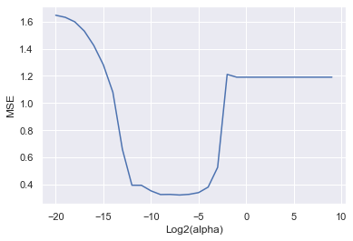

```python
plt.plot([i for i in range(-20, 10)], mse_list)
plt.xlabel('Log2(alpha)')
plt.ylabel("MSE")
```

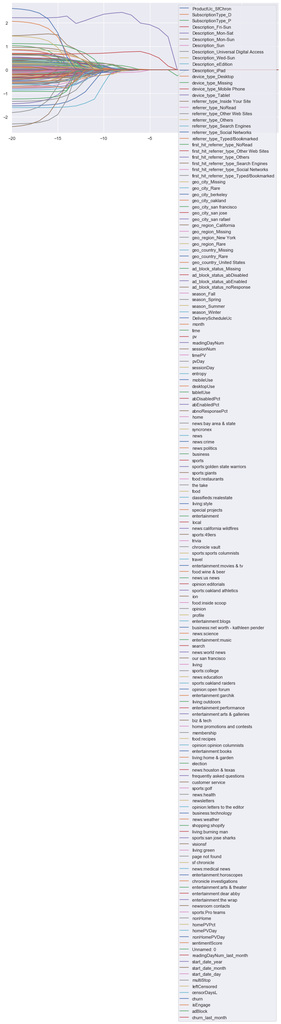

```python
coefs.T.plot(figsize=(12,6))
```

```python
print('Prediction logReadingDayNum_next_month using Lasso:')
clf = linear_model.Lasso(alpha=0.002, random_state=16889)
clf.fit(X_train, y_train)
y_pred = clf.predict(X_test)
print('R squared:', r2_score(y_test, y_pred))
```

```
Prediction logReadingDayNum_next_month using Lasso:
R squared: 0.6433454878375684
```

```python
# Feature coefficient of Lasso
cols = []
important_features = []
for i in X_train.columns:
    cols.append(i)
l = list(zip(clf.coef_, cols))
for i in l:
     if abs(float(i[0]))>= 0.0000000001:
        important_features.append(i[1])
        print(i)
```

```
(0.03608612620763479, 'SubscriptionType_D')
(0.00930367846869986, 'device_type_Missing')
(-0.037520201819768256, 'referrer_type_Inside Your Site')
(0.012513282968802891, 'referrer_type_NoRead')
(0.017416666226418923, 'first_hit_referrer_type_Others')
(-0.04908861856524919, 'first_hit_referrer_type_Search Engines')
(-0.0373680867195186, 'geo_city_Rare')
(-0.0005108435667920355, 'geo_country_United States')
(0.11427155583962159, 'ad_block_status_Missing')
(-0.3154265445954769, 'season_Fall')
(0.030823450621120036, 'season_Spring')
(0.037668093528035476, 'season_Summer')
(-0.04146572599199316, 'season_Winter')
(-0.277889468031274, 'month')
(2.5215114455435836, 'readingDayNum')
(0.005722725676648374, 'mobileUse')
(-0.0010179474780750047, 'desktopUse')
(-0.022969526224206952, 'abDisabledPct')
(0.07779886728385092, 'home')
(0.16133460162109192, 'news:bay area & state')
(-0.015296305344501972, 'syncronex')
(0.17856801962087102, 'news')
(0.024253774032213418, 'news:politics')
(0.056751670652031495, 'sports:golden state warriors')
(0.0999285058234469, 'sports:giants')
(0.010872169999993951, 'sports:sports columnists')
(-0.11635106304309151, 'entertainment:blogs')
(-0.1828878805511813, 'Unnamed: 0')
(0.5658518996434834, 'readingDayNum_last_month')
(-0.25490101411100163, 'start_date_year')
(-0.2847779978743844, 'start_date_month')
(-0.003954028133517294, 'start_date_day')
(-0.0518202205217224, 'multiStop')
(-0.14387329133439802, 'isEngage')
```

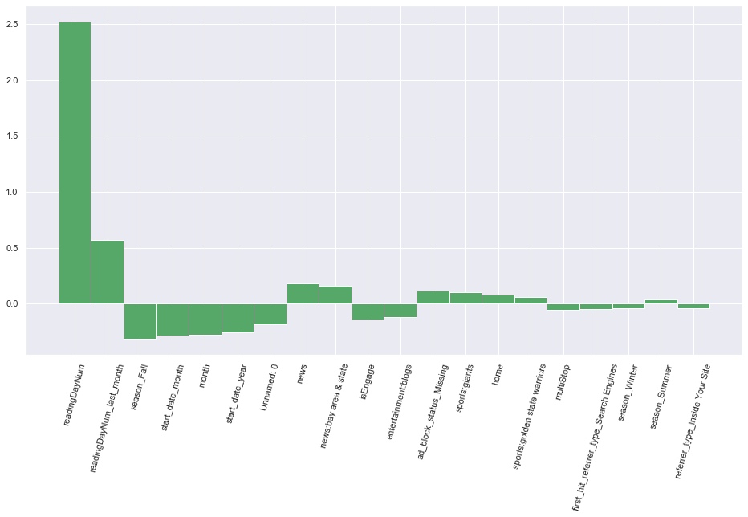

```python
# Ranked Feature coefficient:
coef_dict = {}
for coef, feat in zip(clf.coef_,cols):
    coef_dict[feat] = coef
sorted_x = dict(sorted(coef_dict.items(), key=lambda kv: abs(kv[1]), reverse=True)[:20])
fig = plt.gcf()
fig.set_size_inches(16,8, forward = False)
plt.bar(sorted_x.keys(), sorted_x.values(), width = 1, color='g')
plt.xticks(rotation = 75)
plt.show()
```

```python
print('Prediction logReadingDayNum_next_month using Lasso_filtered_features + NN:')
clf = MLPRegressor(solver='adam',activation='tanh', alpha=0.035,learning_rate = 'adaptive',
                   hidden_layer_sizes=(20,10,5,5,2),max_iter = 2000, random_state=1108,
                   early_stopping = False)
clf.fit(X_train[important_features], y_train)
predictions = clf.predict(X_test[important_features])
print('r2_score: ', r2_score(y_test, predictions))
```

```
Prediction logReadingDayNum_next_month using Lasso_filtered_features + NN:
r2_score:  0.7210972708595389
```

```python
print('Prediction logReadingDayNum_next_month using PCA_filtered_features + NN:')
clf = MLPRegressor(solver='adam',activation='tanh', alpha=0.025,learning_rate = 'adaptive',
                   hidden_layer_sizes=(15,10,5),
                   max_iter = 2000, random_state=1108,
                   early_stopping = False)
clf.fit(X_train_pca, y_train)
predictions = clf.predict(X_test_pca)
print('r2_score: ', r2_score(y_test, predictions))
```

```
Prediction logReadingDayNum_next_month using PCA_filtered_features + NN:
r2_score:  0.4399702337121192
```

```python
# # Visualization of NN: need to install a package before run this cell
# # Clone: https://github.com/jzliu-100/visualize-neural-network/blob/master/VisualizeNN.py
# import VisualizeNN as VisNN

# fig = plt.gcf()
# fig.set_size_inches(15,25, forward = False)
# network_structure = np.hstack(([X_train[important_features].shape[1]], np.asarray(clf.hidden_layer_sizes), 1))
# network=VisNN.DrawNN(network_structure, clf.coefs_)
# network.draw()
```

```python
print('Prediction logReadingDayNum_next_month using Lasso_filtered_features + LGBM:')
lgbm = LGBMRegressor(boosting_type='gbdt', num_leaves=31, max_depth= 8, learning_rate=0.01,
            n_estimators=1000, max_bin=255, subsample_for_bin=50000,
                     reg_alpha=0.25, reg_lambda=0.3, seed=1108)
lgbm.fit(X_train[important_features], y_train)
predictions = lgbm.predict(X_test[important_features])
print('r2_score: ', r2_score(y_test, predictions))
```

```
Prediction logReadingDayNum_next_month using Lasso_filtered_features + LGBM:
r2_score:  0.7317713464247672
```

```python
print('Prediction logReadingDayNum_next_month using Lasso_filtered_features + RandomForest:')
regr = RandomForestRegressor(max_depth=5, random_state=1108,
                              n_estimators=100)
regr.fit(X_train[important_features], y_train)
y_pred = regr.predict(X_test[important_features])
print('R squared:', r2_score(y_test, y_pred))
```

```
Prediction logReadingDayNum_next_month using Lasso_filtered_features + RandomForest:
R squared: 0.7091370115239134
```

```python
print('Prediction logReadingDayNum_next_month RandomForest:')
regr = RandomForestRegressor(max_depth=10, random_state=1108,
                              n_estimators=100)
regr.fit(X_train, y_train)
y_pred = regr.predict(X_test)
print('R squared:', r2_score(y_test, y_pred))
```

```
Prediction logReadingDayNum_next_month RandomForest:
R squared: 0.5101610059300105
```

```python
regr.feature_importances_
```

```
array([0.00000000e+00, 9.66049997e-05, 1.44827500e-04, 1.51875440e-04,
       1.26780108e-05, 2.12364657e-04, 1.39436045e-04, 1.23545801e-04,
       2.70826182e-05, 2.16800305e-07, 1.70754788e-06, 5.96848251e-05,
       0.00000000e+00, 6.12092617e-05, 8.58547890e-05, 7.69625553e-05,
       0.00000000e+00, 5.30326997e-05, 1.05266465e-04, 1.60969134e-04,
       8.75048827e-05, 2.31856307e-04, 0.00000000e+00, 6.64095616e-05,
       1.29942013e-04, 4.50513577e-04, 1.35060451e-04, 1.42877417e-04,
       0.00000000e+00, 2.32343742e-04, 8.43266321e-05, 1.39861366e-04,
       1.81063880e-04, 8.17348646e-05, 5.13027782e-05, 1.92246656e-04,
       0.00000000e+00, 6.89352314e-05, 1.34871536e-04, 0.00000000e+00,
       6.66273246e-05, 2.77314805e-04, 4.49427716e-05, 6.92404140e-05,
       4.05853849e-05, 2.66503568e-05, 1.57989882e-02, 4.19352421e-04,
       6.64282851e-04, 1.39410462e-04, 3.74124320e-04, 7.91799976e-03,
       2.29749985e-03, 2.30239128e-03, 8.72796238e-01, 2.45863139e-03,
       2.31309321e-03, 2.45242824e-03, 1.67336565e-03, 2.95395588e-03,
       5.35760510e-04, 4.43311744e-04, 3.86976313e-04, 1.08498100e-03,
       8.81388515e-04, 1.05921107e-03, 6.44005042e-04, 1.92191299e-03,
       3.36911602e-03, 7.83526629e-04, 6.01062234e-04, 7.89304328e-04,
       5.64379333e-04, 5.38663542e-04, 5.64027282e-04, 4.60889425e-04,
       3.83289552e-04, 1.73217354e-04, 4.50368174e-04, 2.40876741e-04,
       2.79386821e-04, 8.98960740e-04, 5.35740304e-04, 4.26488000e-04,
       5.66355606e-04, 3.40543295e-04, 5.98684916e-05, 3.67826893e-04,
       3.00921831e-04, 2.79953590e-04, 2.77766521e-04, 4.79955908e-04,
       2.57004859e-04, 3.93413924e-04, 4.11195700e-04, 6.24523509e-04,
       1.76833341e-04, 2.72047081e-04, 7.16443839e-04, 1.32856782e-03,
       2.36731883e-04, 3.37634214e-04, 1.95046754e-04, 3.55222863e-04,
       2.56899902e-04, 1.43849866e-04, 1.06444435e-04, 3.68807326e-04,
       2.90192056e-04, 2.55042232e-04, 2.69415890e-04, 3.39191155e-04,
       2.88417806e-04, 7.04616460e-05, 1.06786658e-04, 1.74023048e-04,
       2.19587615e-04, 4.21613215e-04, 1.53271544e-04, 1.39857409e-04,
       1.75057515e-04, 8.76576126e-05, 1.33886608e-04, 1.29618545e-04,
       2.00686439e-04, 4.58745222e-04, 8.55509506e-06, 1.73733780e-04,
       1.33098675e-04, 1.73910972e-04, 7.81409611e-05, 9.76544270e-06,
       1.78963838e-05, 9.80498281e-05, 1.30993373e-04, 2.52673039e-05,
       6.75688189e-05, 1.97427793e-05, 6.70234577e-05, 3.26855290e-05,
       2.57695759e-06, 2.52902165e-05, 1.81764499e-05, 1.27743227e-04,
       1.33674789e-04, 1.72075895e-05, 2.63146416e-06, 8.90600676e-04,
       1.59342008e-03, 7.10710004e-04, 1.03348251e-03, 2.18203906e-03,
       1.73778296e-02, 1.42007696e-02, 3.61673300e-04, 1.56353006e-03,
       6.61431552e-03, 1.48313257e-03, 0.00000000e+00, 0.00000000e+00,
       0.00000000e+00, 7.88466954e-04, 4.07895211e-05, 0.00000000e+00])
```

```python
print('Prediction logReadingDayNum_next_month using PCA_filtered_features + RandomForest:')
regr = RandomForestRegressor(max_depth=40, random_state=1108,
                              n_estimators=100)
regr.fit(X_train_pca, y_train)
y_pred = regr.predict(X_test_pca)
print('R squared:', r2_score(y_test, y_pred))
```

```
Prediction logReadingDayNum_next_month using PCA_filtered_features + RandomForest:
R squared: 0.4363522123172179
```

### Q2: Prediction of churn_next_month (AUC)

```python
y_train = churn_next_month_train
y_test = churn_next_month_test
```

```python
print('Prediction churn_next_month using LogisticRegression:')
model = LogisticRegression(max_iter=1000, solver="lbfgs")
model.fit(X_train, y_train)
predictions = model.predict(X_test)
print('AUC: ', roc_auc_score(y_test, predictions))
```

```
Prediction churn_next_month using LogisticRegression:
AUC:  0.6631529260547708
```

```python
# Lasso Path
y_train1 = churn_next_month_train[:2000].copy()
y_test1 = churn_next_month_test[:1000].copy()
c_list = [2**(-i) for i in range(-20 , 10)]
coefs_df = []
AUC_list = []

for i in c_list:
    clf = LogisticRegression(penalty="l1",solver='liblinear', C = i, random_state=123)
    clf.fit(X_train[:2000], y_train1)
    y_pred = clf.predict(X_test[:1000])

    AUC_list.append(roc_auc_score(y_test1, y_pred))
    # store the coefficients of the variables in a list
    coefs_df.append(pd.Series(clf.coef_.ravel()))

coefs = pd.concat(coefs_df, axis=1)
coefs.columns = [i for i in range(-20 , 10)]
coefs.index = X_train.columns
```

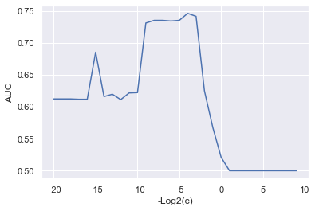

```python
plt.plot([i for i in range(-20 , 10)], AUC_list)
plt.xlabel('-Log2(c)')
plt.ylabel("AUC")
```

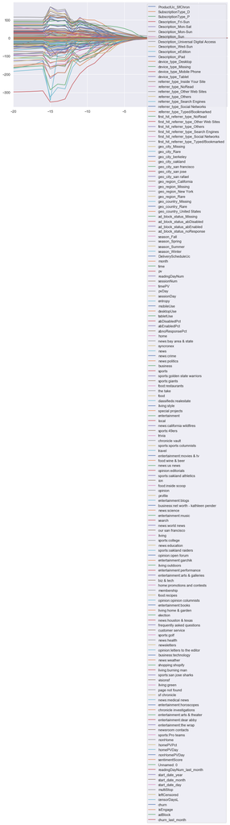

```python
coefs.T.plot(figsize=(12,6))
```

```python
clf = LogisticRegression(penalty="l1",solver='liblinear', C = 8, random_state=123)
clf.fit(X_train, churn_next_month_train)
predictions = clf.predict(X_test)
print('Prediction churn_next_month using Lasso + LogisticRegression:')
print('AUC: ', roc_auc_score(churn_next_month_test, predictions))
```

```
Prediction churn_next_month using Lasso + LogisticRegression:
AUC:  0.7988926306821535
```

```python
cols = []

important_features = []
for i in X_train.columns:
    cols.append(i)
l = list(zip(clf.coef_.tolist()[0], cols))
for i in l:
     if abs(float(i[0]))>= 0.1:
        important_features.append(i[1])
        print(i)
```

```
(-2.71661353496478, 'ProductUc_SfChron')
(-2.183120940791721, 'SubscriptionType_D')
(-2.7611861561097313, 'SubscriptionType_P')
(-0.21651575290004843, 'Description_Mon-Sun')
(-0.17380369538994725, 'Description_Sun')
(4.149119868801303, 'Description_Wed-Sun')
(-0.5324058226518593, 'Description_eEdition')
(-0.447602535360494, 'device_type_Desktop')
(-0.5072641062027562, 'device_type_Missing')
(-0.861666255161722, 'device_type_Mobile Phone')
(-0.5833858718329806, 'referrer_type_NoRead')
(-0.322776299205965, 'referrer_type_Search Engines')
(-0.24208212837053758, 'referrer_type_Typed/Bookmarked')
(-0.8077888828640939, 'first_hit_referrer_type_NoRead')
(-0.5337968856068179, 'first_hit_referrer_type_Others')
(-0.3397792502537225, 'first_hit_referrer_type_Social Networks')
(-0.1926119259105329, 'first_hit_referrer_type_Typed/Bookmarked')
(-1.4352283848486387, 'geo_city_Missing')
(-0.11602179592032946, 'geo_city_oakland')
(0.3981168385459541, 'geo_city_san jose')
(-0.17246943941463178, 'geo_city_san rafael')
(-1.0968928543220349, 'geo_region_California')
(-0.2783169282565686, 'geo_region_Missing')
(-1.2264523087179224, 'geo_region_Rare')
(-0.6453433635308793, 'geo_country_Missing')
(-0.6367303320504963, 'geo_country_Rare')
(-1.0919258875273126, 'geo_country_United States')
(-0.3959067181319832, 'ad_block_status_Missing')
(-0.349369118424898, 'ad_block_status_abDisabled')
(-0.824722018844385, 'ad_block_status_noResponse')
(-1.3032126969452338, 'season_Fall')
(-1.3929568468761229, 'season_Spring')
(-1.269934196348498, 'season_Winter')
(-0.44340502153876704, 'DeliveryScheduleUc')
(2.3997311092084948, 'month')
(1.3378144808457528, 'time')
(1.2936534482920092, 'readingDayNum')
(-0.9289899941757412, 'timePV')
(-0.5583223813448202, 'sessionDay')
(-0.2366454379039557, 'entropy')
```

[output cut: 71 more lines]

```
(1.3632839638040248, 'newsroom contacts')
(0.8098141593281472, 'sports:Pro teams')
(-5.188612721246548, 'nonHome')
(-0.5334885921087761, 'homePVPct')
(-0.8328321329013023, 'homePVDay')
(2.844675864655133, 'nonHomePVDay')
(-1.5973730780177682, 'sentimentScore')
(0.14388136492073497, 'Unnamed: 0')
(0.5146275221345548, 'readingDayNum_last_month')
(1.5664626304557083, 'start_date_year')
(1.5064849623966923, 'start_date_month')
(0.46037458202454895, 'start_date_day')
(12.131655993997388, 'multiStop')
(-2.2356535763866434, 'isEngage')
(-0.6377659068946523, 'adBlock')
```

```python
coef_dict = {}
for coef, feat in zip(clf.coef_[0],cols):
    coef_dict[feat] = coef
sorted_x = dict(sorted(coef_dict.items(), key=lambda kv: abs(kv[1]), reverse=True)[:30])
```

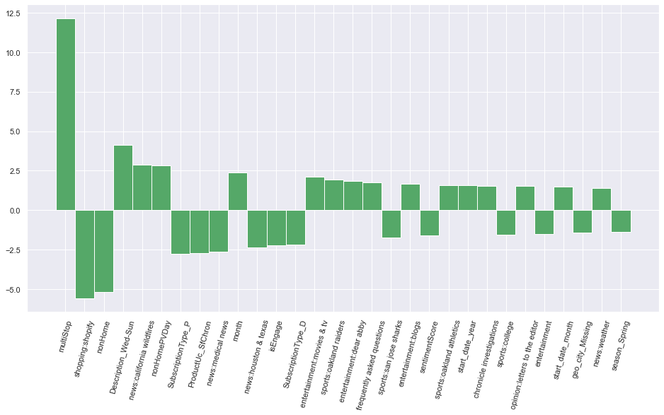

```python
fig = plt.gcf()
fig.set_size_inches(16,8, forward = False)
plt.bar(sorted_x.keys(), sorted_x.values(), width = 1, color='g')
plt.xticks(rotation = 75)
plt.show()
```

```python
print('Prediction churn_next_month using Lasso + RandomForest:')
model = RandomForestClassifier(max_depth= 50, random_state=1108,
                              n_estimators=100)
model.fit(X_train[important_features], y_train)
predictions = model.predict(X_test[important_features])
print('AUC: ', roc_auc_score(y_test, predictions))
```

```
Prediction churn_next_month using Lasso + RandomForest:
AUC:  0.6233401791897939
```

```python
print('Prediction churn_next_month using Lasso + NN:')
model = MLPClassifier(solver='adam',activation='tanh', alpha=0.02,learning_rate = 'adaptive',
                      hidden_layer_sizes=(20,6),max_iter = 1000, random_state=1108,
                      early_stopping = False)
model.fit(X_train[important_features], y_train)
predictions = model.predict(X_test[important_features])
print('AUC: ', roc_auc_score(y_test, predictions))
```

```
Prediction churn_next_month using Lasso + NN:
AUC:  0.6738777685302165
```

### Q3: Prediction of soft_churn_next_month (AUC)

```python
y_train = soft_churn_next_month_train
y_test = soft_churn_next_month_test
```

```python
print('Prediction soft_churn_next_month using LogisticRegression:')
model = LogisticRegression(max_iter=1000, solver="lbfgs")
model.fit(X_train, y_train)
predictions = model.predict(X_test)
print('AUC: ', roc_auc_score(y_test, predictions))
```

```
Prediction soft_churn_next_month using LogisticRegression:
AUC:  0.8070323805518794
```

```python
# Lasso Path
y_train1 = soft_churn_next_month_train[:2000].copy()
y_test1 = soft_churn_next_month_test[:1000].copy()
c_list = [2**(-i/2) for i in range(-30 , 30)]
coefs_df = []
AUC_list = []

for i in c_list:
    clf = LogisticRegression(penalty="l1",solver='liblinear', C = i, random_state=123)
    clf.fit(X_train[:2000], y_train1)
    y_pred = clf.predict(X_test[:1000])

    AUC_list.append(roc_auc_score(y_test1, y_pred))
    # store the coefficients of the variables in a list
    coefs_df.append(pd.Series(clf.coef_.ravel()))

coefs = pd.concat(coefs_df, axis=1)
coefs.columns = [i/2.0 for i in range(-30 , 30)]
coefs.index = X_train.columns
```

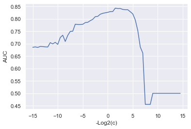

```python
plt.plot([i/2.0 for i in range(-30 , 30)], AUC_list)
plt.xlabel('-Log2(c)')
plt.ylabel("AUC")
```

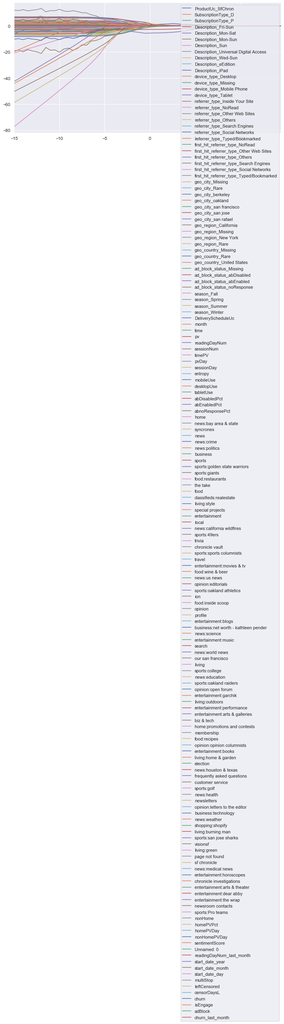

```python
coefs.T.plot(figsize=(12,6))
```

```python
clf = LogisticRegression(penalty="l1",solver='liblinear', C = 0.2, random_state=123)
clf.fit(X_train, soft_churn_next_month_train)
predictions = clf.predict(X_test)
print('Prediction soft_churn_next_month using Lasso + LogisticRegression:')
print('AUC: ', roc_auc_score(soft_churn_next_month_test, predictions))
```

```
Prediction soft_churn_next_month using Lasso + LogisticRegression:
AUC:  0.8050409226399629
```

```python
# reduce penalty to get more features for further calculation
clf = LogisticRegression(penalty="l1",solver='liblinear', C = 1, random_state=123)
clf.fit(X_train, rock_star_next_month_train)

cols = []

important_features = []
for i in X_train.columns:
    cols.append(i)
l = list(zip(clf.coef_.tolist()[0], cols))
for i in l:
     if abs(float(i[0]))>= 0.01:
        important_features.append(i[1])
        print(i)
print(important_features)
```

```
(-1.3463279255110994, 'ProductUc_SfChron')
(-0.16305240043646674, 'SubscriptionType_P')
(-0.12747195677805495, 'Description_Fri-Sun')
(-0.10477464881579972, 'device_type_Mobile Phone')
(-0.16966496222894456, 'device_type_Tablet')
(0.19804627769540628, 'referrer_type_Others')
(-0.3412240304322848, 'referrer_type_Search Engines')
(-0.0948069049814834, 'referrer_type_Social Networks')
(-0.413158916599725, 'referrer_type_Typed/Bookmarked')
(0.5112050594655181, 'first_hit_referrer_type_Other Web Sites')
(-0.2115594083333304, 'first_hit_referrer_type_Others')
(-0.10952535487660352, 'first_hit_referrer_type_Search Engines')
(-0.3063828530537286, 'first_hit_referrer_type_Social Networks')
(-0.01741903468259891, 'geo_city_Rare')
(0.10315083833235043, 'geo_city_oakland')
(-0.03475803336609716, 'geo_city_san jose')
(-0.17931339043678418, 'geo_city_san rafael')
(-0.5544908249023704, 'geo_region_New York')
(-0.22430812445191495, 'geo_region_Rare')
(-0.1861783210075705, 'geo_country_Rare')
(-0.26006653009386993, 'geo_country_United States')
(-0.15402667178020146, 'ad_block_status_abEnabled')
(-0.24083148820066072, 'ad_block_status_noResponse')
(-2.4531306540871327, 'season_Fall')
(0.703480882390626, 'season_Summer')
(-0.7410551719771632, 'season_Winter')
(-3.4757427635475757, 'month')
(8.60920138778376, 'readingDayNum')
(3.0568203667610403, 'sessionNum')
(0.22549670048061507, 'timePV')
(-3.9310572928802654, 'pvDay')
(-1.5666107730808592, 'entropy')
(0.07357780085925644, 'mobileUse')
(-0.07495373099428872, 'desktopUse')
(0.19035466609875207, 'tabletUse')
(-0.25801589466942515, 'abDisabledPct')
(0.6856097869918715, 'abEnabledPct')
(0.6167159395403726, 'abnoResponsePct')
(0.8123562667270531, 'news:bay area & state')
(0.8340050659568345, 'syncronex')
```

[output cut: 52 more lines]

```
(-0.7244808517918666, 'living:green')
(1.6448252741695668, 'entertainment:horoscopes')
(-0.17480086651655805, 'chronicle investigations')
(1.265174827702818, 'sports:Pro teams')
(3.512597142050928, 'nonHome')
(2.0645602371879326, 'homePVPct')
(-1.2793998856805173, 'homePVDay')
(-0.5227548303926081, 'Unnamed: 0')
(1.4700970814838252, 'readingDayNum_last_month')
(-2.985277408837035, 'start_date_year')
(-2.884013029513287, 'start_date_month')
(-0.73100398069639, 'multiStop')
(-4.91984952715706, 'isEngage')
(-0.5119335915181543, 'adBlock')
['ProductUc_SfChron', 'SubscriptionType_P', 'Description_Fri-Sun', 'device_type_Mobile Phone', 'device_type_Tablet', 'referrer_type_Others', 'referrer_type_Search Engines', 'referrer_type_Social Networks', 'referrer_type_Typed/Bookmarked', 'first_hit_referrer_type_Other Web Sites', 'first_hit_referr…
```

```python
coef_dict = {}
for coef, feat in zip(clf.coef_[0],cols):
    coef_dict[feat] = coef
sorted_x = dict(sorted(coef_dict.items(), key=lambda kv: abs(kv[1]), reverse=True)[:20])
```

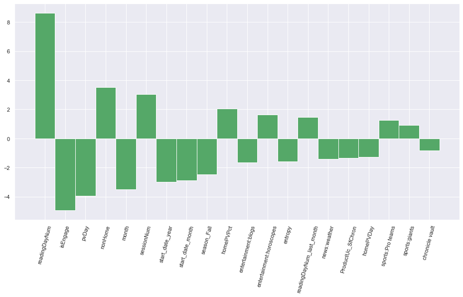

```python
fig = plt.gcf()
fig.set_size_inches(16,8, forward = False)
plt.bar(sorted_x.keys(), sorted_x.values(), width = 1, color='g')
plt.xticks(rotation = 75)
plt.show()
```

```python
print('Prediction soft_churn_next_month using Lasso + RandomForest:')
model = RandomForestClassifier(max_depth= 50, random_state=1108,
                              n_estimators=100)
model.fit(X_train[important_features], y_train)
predictions = model.predict(X_test[important_features])
print('AUC: ', roc_auc_score(y_test, predictions))
```

```
Prediction soft_churn_next_month using Lasso + RandomForest:
AUC:  0.8411542107198314
```

```python
print('Prediction soft_churn_next_month using Lasso + NN:')
model = MLPClassifier(solver='adam',activation='tanh', alpha=0.02,learning_rate = 'adaptive',
                      hidden_layer_sizes=(20,6),max_iter = 1000, random_state=1108,
                      early_stopping = False)
model.fit(X_train[important_features], y_train)
predictions = model.predict(X_test[important_features])
print('AUC: ', roc_auc_score(y_test, predictions))
```

```
Prediction soft_churn_next_month using Lasso + NN:
AUC:  0.8412138040683141
```

### Q4: predict rock_star_next_month (AUC)

```python
y_train = rock_star_next_month_train
y_test = rock_star_next_month_test
```

```python
print('Prediction rock_star_next_month using LogisticRegression:')
model = LogisticRegression(max_iter=1000, solver="lbfgs")
model.fit(X_train, y_train)
predictions = model.predict(X_test)
print('AUC: ', roc_auc_score(y_test, predictions))
```

```
Prediction rock_star_next_month using LogisticRegression:
AUC:  0.7241813534119016
```

```python
# Lasso Path
y_train1 = rock_star_next_month_train[:2000]
y_test1 = rock_star_next_month_test[:1000]
c_list = [2**(-i/2) for i in range(-20 , 20)]
coefs_df = []
AUC_list = []

for i in c_list:
    clf = LogisticRegression(penalty="l1",solver='liblinear', C = i, random_state=123)
    clf.fit(X_train[:2000], y_train1)
    y_pred = clf.predict(X_test[:1000])

    AUC_list.append(roc_auc_score(y_test1, y_pred))
    # store the coefficients of the variables in a list
    coefs_df.append(pd.Series(clf.coef_.ravel()))

coefs = pd.concat(coefs_df, axis=1)
coefs.columns = [i/2.0 for i in range(-20 , 20)]
coefs.index = X_train.columns
```

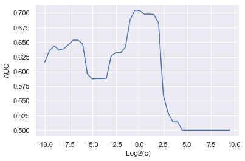

```python
plt.plot([i/2.0 for i in range(-20 , 20)], AUC_list)
plt.xlabel('-Log2(c)')
plt.ylabel("AUC")
```

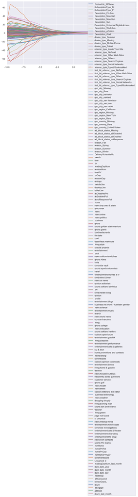

```python
coefs.T.plot(figsize=(12,6))
```

```python
print('Prediction rock_star_next_month using Lasso + LogisticRegression:')
clf = LogisticRegression(penalty="l1",solver='liblinear', C = 3, random_state=123)
clf.fit(X_train, rock_star_next_month_train)
predictions = clf.predict(X_test)
print('AUC: ', roc_auc_score(rock_star_next_month_test, predictions))
```

```
Prediction rock_star_next_month using Lasso + LogisticRegression:
AUC:  0.7131277491920506
```

```python
# reduce penalty to get more features for further calculation
clf = LogisticRegression(penalty="l1",solver='liblinear', C = 10, random_state=123)
clf.fit(X_train, rock_star_next_month_train)

cols = []

important_features = []
for i in X_train.columns:
    cols.append(i)
l = list(zip(clf.coef_.tolist()[0], cols))
for i in l:
     if abs(float(i[0]))>= 0.1:
        important_features.append(i[1])
        print(i)
```

```
(-1.0899130365538356, 'ProductUc_SfChron')
(-1.6182170163633314, 'SubscriptionType_D')
(-1.7510043330705387, 'SubscriptionType_P')
(-0.2295693330917097, 'Description_Fri-Sun')
(0.22535050491644681, 'Description_Wed-Sun')
(-1.0204359917832064, 'Description_iPad')
(-0.4088856181584545, 'device_type_Desktop')
(0.959157289070087, 'device_type_Missing')
(-0.5803358161788796, 'device_type_Mobile Phone')
(-0.675237158371256, 'device_type_Tablet')
(0.7299777745644177, 'referrer_type_NoRead')
(0.21704482836009903, 'referrer_type_Others')
(-0.4288169762436983, 'referrer_type_Search Engines')
(-0.17172505872262347, 'referrer_type_Social Networks')
(-0.5000265005755348, 'referrer_type_Typed/Bookmarked')
(0.8428147060967517, 'first_hit_referrer_type_NoRead')
(0.155985972391087, 'first_hit_referrer_type_Other Web Sites')
(-0.7306234795603601, 'first_hit_referrer_type_Others')
(-0.6076788787329037, 'first_hit_referrer_type_Search Engines')
(-0.8038924252768687, 'first_hit_referrer_type_Social Networks')
(-0.48890146252630584, 'first_hit_referrer_type_Typed/Bookmarked')
(0.47557564404309044, 'geo_city_Missing')
(-0.13887644175987549, 'geo_city_Rare')
(-0.13789007777241497, 'geo_city_berkeley')
(-0.12786670220384624, 'geo_city_san francisco')
(-0.20138331446684934, 'geo_city_san jose')
(-0.3501976045923834, 'geo_city_san rafael')
(-0.35595361069458265, 'geo_region_California')
(0.4617530336306307, 'geo_region_Missing')
(-1.0165383025343646, 'geo_region_New York')
(-0.5765690699783608, 'geo_region_Rare')
(1.1610756952211434, 'geo_country_Missing')
(-0.5649114830532023, 'geo_country_Rare')
(-0.5802130665110674, 'geo_country_United States')
(-2.3515513649912227, 'ad_block_status_Missing')
(-0.13191367992476213, 'ad_block_status_abDisabled')
(-0.27326355166927896, 'ad_block_status_abEnabled')
(-0.5360963957185212, 'ad_block_status_noResponse')
(-3.0288614414069794, 'season_Fall')
(-0.4712316897030007, 'season_Spring')
```

[output cut: 79 more lines]

```
(0.7127920309834097, 'entertainment:arts & theater')
(-0.42619724666040304, 'entertainment:the wrap')
(1.7328029561637293, 'sports:Pro teams')
(4.034210249040634, 'nonHome')
(2.4372995979715415, 'homePVPct')
(-1.2165876182475956, 'homePVDay')
(0.894744363564879, 'nonHomePVDay')
(-0.20989583951897053, 'sentimentScore')
(-0.564097584275084, 'Unnamed: 0')
(1.4638169388590454, 'readingDayNum_last_month')
(-3.113140463491344, 'start_date_year')
(-3.0133379918727212, 'start_date_month')
(-0.7570836253192182, 'multiStop')
(-0.9750614807354403, 'isEngage')
(-0.7937243463953091, 'adBlock')
```

```python
coef_dict = {}
for coef, feat in zip(clf.coef_[0],cols):
    coef_dict[feat] = coef
sorted_x = dict(sorted(coef_dict.items(), key=lambda kv: abs(kv[1]), reverse=True)[:30])
```

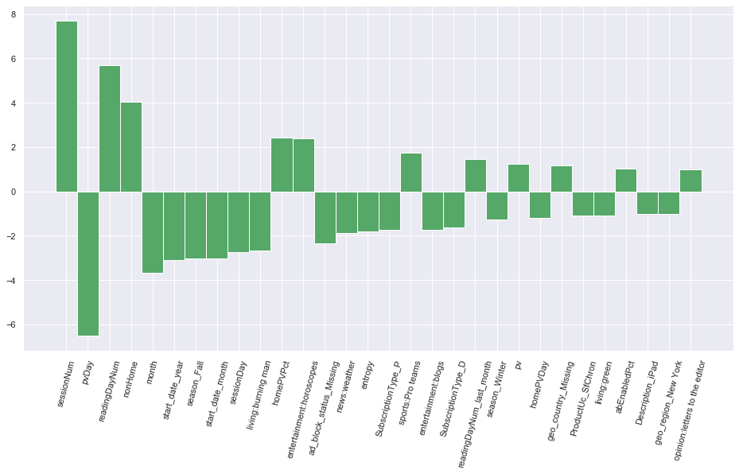

```python
fig = plt.gcf()
fig.set_size_inches(16,8, forward = False)
plt.bar(sorted_x.keys(), sorted_x.values(), width = 1, color='g')
plt.xticks(rotation = 75)
plt.show()
```

```python
print('Prediction rock_star_next_month using Lasso + RandomForest:')
model = RandomForestClassifier(max_depth= 30, random_state=1108,
                              n_estimators=100)
model.fit(X_train[important_features], y_train)
predictions = model.predict(X_test[important_features])
print('AUC: ', roc_auc_score(y_test, predictions))
```

```
Prediction rock_star_next_month using Lasso + RandomForest:
AUC:  0.8117691604380656
```

```python
# NN
print('Prediction rock_star_next_month using Lasso + NN:')
clf = MLPClassifier(solver='adam',activation='tanh', alpha=0.01,learning_rate = 'adaptive',
                   hidden_layer_sizes=(5,3),max_iter = 2000, random_state=16889,
                   early_stopping = True)
clf.fit(X_train[important_features], y_train)
predictions = clf.predict(X_test[important_features])
print('AUC: ', roc_auc_score(y_test, predictions))
```

```
Prediction rock_star_next_month using Lasso + NN:
AUC:  0.8467638203168584
```

```python
print('Prediction rock_star_next_month using PCA + NN:')
clf = MLPClassifier(solver='adam',activation='tanh', alpha=0.01,learning_rate = 'adaptive',
                   hidden_layer_sizes=(5,3),max_iter = 2000, random_state=16889,
                   early_stopping = True)
clf.fit(X_train_pca, y_train)
predictions = clf.predict(X_test_pca)
print('AUC: ', roc_auc_score(y_test, predictions))
```

```
Prediction rock_star_next_month using PCA + NN:
AUC:  0.7416619328989973
```

### Summary

#### Best models

Predict Churn (binary classification): Lasso for features selection + Logistic Regression AUC: 0.798

Predict Soft Churn (binary classification): Lasso for features selection + NN/RF AUC: 0.841

Predict Rock Star (binary classification): Lasso for features selection + NN AUC: 0.847

#### Powerful predictors and implication

Predict next period Regularity(Log Reading day next month):

readingDayNum; readingDayNum_last_month; Start_day; Month; season...

Predict Churn (binary classification):

Multi-stop; Shopping; Non-home; Wed- Sun;  
Wirefile...

Predict Soft Churn (binary classification)

readingDayNum; isEngage; Pv/Day; Non-home; Month...

Predict Rock Star (binary classification):

Session number;  
Reading day number; pv/Day; Start day year/ month; News : bay area...

#### Next Step:

After we identify soft churn/hard churn, we can prevent users from churnning by:

Further segmentation and customize contents : bay area local news, medical, entertainment topics etc

Deliver through a personalized way : personalized newsletter